# Analysis of the Corpus of Oz Early English - Part 1: Data Preparation

Anonymous

2021-12-27

# 1 Introduction

This document shows an analysis of Corpus of Oz Early English (COOEE) (Fritz 2004).

## 1.1 Aims

- Find keywords
- Find keywords for periods
- Create network of keywords (network analysis)
- Find topics (topic modeling)

# 2 Data Processing

In a first step, the session is prepared by installing packages.

```r
# install packages
install.packages("corpus")
install.packages("here")
install.packages("lubridate")
install.packages("ngram")
install.packages("qdap")
install.packages("quanteda")
install.packages("quanteda.textmodels")
install.packages("quanteda.textplots")
install.packages("quanteda.textstats")
install.packages("rgdal")
install.packages("seededlda")
install.packages("textstem")
install.packages("tidyr")
install.packages("tidytext")
install.packages("tidyverse")
install.packages("tm")
install.packages("tmap")
install.packages("tokenizers")
```

Now, we activate the packages, set options, load relevant functions, and defining the path to the data.

```r
# set options
options(stringsAsFactors = F)
options(scipen = 999)
# load packages
library(corpus)
library(here)
library(lubridate)
library(ngram)
library(qdap)
library(quanteda)
library(quanteda.textmodels)
```

```r
library(quanteda.textplots)
library(quanteda.textstats)
library(rgdal)
library(seededlda)
library(textstem)
library(tidyr)
library(tidytext)
library(tidyverse)
library(tm)
library(tmap)
library(tokenizers)
# specify path to corpus
corpuspath <- "D:\\Uni\\Korpora\\Original\\COOEE\\COOEE-single_files"
# specify path to metadata
metapath <- "D:\\Uni\\Korpora\\Original\\COOEE/COOEE.XLS"
# load shape files
ozmap <- readOGR(dsn = here::here("data/shapes", "AshmoreAndCartierIslands.shp"),
                 stringsAsFactors = F)
```

# 3 COOEE

We now load and process the *Corpus of Oz Early English* (COOEE) (Fritz 2004). .

```r
# load corpus files
cooeefiles = list.files(path = corpuspath, all.files = T, full.names = T, recursive = T, ignore.case = T, include.dirs = T)
# load and unlist corpus
cooee <- sapply(cooeefiles, function(x) {
  x <- scan(x, what = "char", sep = "", quote = "\"", quiet = T, skipNul = T)
  x <- stringr::str_squish(x)
  x <- paste0(x, collapse = " ")
  x <- unlist(x)
} )
# inspect data
str(cooee)
```

```
##  Named chr [1:1354] "<source><g=m><o=b><age=50><status=1><abode=00><p=nsw><r=prw><tt=pc><1-001> Dear Sir, I have the pleasure of sen"| __truncated__ ...
##  - attr(*, "names")= chr [1:1354] "D:\\Uni\\Korpora\\Original\\COOEE\\COOEE-single_files/1-001.txt" "D:\\Uni\\Korpora\\Original\\COOEE\\COOEE-single_files/1-002.txt" "D:\\Uni\\Korpora\\Original\\COOEE\\COOEE-single_files/1-003.txt" "D:\\Uni\\Korpora\\Original\\COOEE\\COOEE-single_files/1-004.txt"…
```

Convert data into a data frame.

```r
cooeedf <- data.frame(cooeefiles, cooee) %>%
  dplyr::rename(Nr = colnames(.)[1],
                Rawtext = colnames(.)[2]) %>%
  dplyr::mutate(Nr = stringr::str_replace_all(Nr, ".*/(.*).txt", "\\1")) %>%
  as.tibble()
# inspect
head(cooeedf)
```

```
## # A tibble: 6 x 2
##   Nr    Rawtext
##   <chr> <chr>
## 1 1-001 "<source><g=m><o=b><age=50><status=1><abode=00><p=nsw><r=prw><tt=pc><1-~
## 2 1-002 "<source><g=m><o=b><age=50><status=1><abode=00><p=nsw><r=gen><tt=ic><1-~
## 3 1-003 "<source><g=m><o=b><age=50><status=1><abode=00><p=nsw><r=gen><tt=ic><1-~
## 4 1-004 "<source><g=m><o=b><age=50><status=1><abode=00><p=nsw><r=gen><tt=ic><1-~
## 5 1-005 "<source><g=m><o=b><age=50><status=1><abode=00><p=nsw><r=gen><tt=ic><1-~
## 6 1-006 "<source><g=m><o=b><age=50><status=1><abode=00><p=nsw><r=gen><tt=ic><1-~
```

Extract metadata (corpus, file, date, etc.)

```r
meta <- readxl::read_xls(metapath)
cnames <- as.vector(unlist(meta[1,])) %>%
  stringr::str_remove_all(" ")
cnames[c(14:16)] <- c("Words", "GenderAddressee", "StatusAddressee")
meta <- meta[2:nrow(meta),]
colnames(meta) <- cnames
meta <- meta  %>%
  dplyr::mutate(id = 1:nrow(.))
# inspect
head(meta)
```

```
## # A tibble: 6 x 20
##   Nr    Name          Birth Gender Origin Age   Status Arrival Abode YearWriting
##   <chr> <chr>         <chr> <chr>  <chr>  <chr> <chr>  <chr>   <chr> <chr>
## 1 1-001 Philip, Arth~ 1738  m      GB     50    I      1788    0     1788
## 2 1-002 Philip, Arth~ 1738  m      GB     50    I      1788    0     1788
## 3 1-003 Philip, Arth~ 1738  m      GB     50    I      1788    0     1788
## 4 1-004 Philip, Arth~ 1738  m      GB     50    I      1788    0     1788
## 5 1-005 Philip, Arth~ 1738  m      GB     50    I      1788    0     1788
## 6 1-006 Philip, Arth~ 1738  m      GB     50    I      1788    0     1788
## # ... with 10 more variables: PlaceWriting <chr>, Register <chr>, TextT <chr>,
## #   Words <chr>, GenderAddressee <chr>, StatusAddressee <chr>, Place <chr>,
## #   Source <chr>, Pages <chr>, id <int>
```

Combine meta data and corpus content

```r
# combine into table
cooeed <- meta %>% dplyr::inner_join(cooeedf, by = "Nr")
# inpspect
head(cooeed)
```

```
## # A tibble: 6 x 21
##   Nr    Name          Birth Gender Origin Age   Status Arrival Abode YearWriting
##   <chr> <chr>         <chr> <chr>  <chr>  <chr> <chr>  <chr>   <chr> <chr>
## 1 1-001 Philip, Arth~ 1738  m      GB     50    I      1788    0     1788
## 2 1-002 Philip, Arth~ 1738  m      GB     50    I      1788    0     1788
## 3 1-003 Philip, Arth~ 1738  m      GB     50    I      1788    0     1788
## 4 1-004 Philip, Arth~ 1738  m      GB     50    I      1788    0     1788
## 5 1-005 Philip, Arth~ 1738  m      GB     50    I      1788    0     1788
## 6 1-006 Philip, Arth~ 1738  m      GB     50    I      1788    0     1788
## # ... with 11 more variables: PlaceWriting <chr>, Register <chr>, TextT <chr>,
## #   Words <chr>, GenderAddressee <chr>, StatusAddressee <chr>, Place <chr>,
## #   Source <chr>, Pages <chr>, id <int>, Rawtext <chr>
```

Process and clean data

```r
# clean files
cooee_clean <- cooeed %>%
  dplyr::mutate(Text = Rawtext) %>%
  dplyr::mutate(Text = stringr::str_remove_all(Text, "\\[/{0,1}.*?\\]"),
                Text = stringr::str_remove_all(Text, "\\</{0,1}.*?\\>"),
                Text = stringr::str_remove_all(Text, "\\{|\\}"),
                Datecat = dplyr::case_when(as.numeric(YearWriting) < 1800 ~ "1788-1800",
                                           as.numeric(YearWriting) < 1820 ~ "1801-1820",
                                           as.numeric(YearWriting) < 1840 ~ "1821-1840",
                                           as.numeric(YearWriting) < 1860 ~ "1841-1860",
                                           as.numeric(YearWriting) < 1880 ~ "1861-1880",
                                           as.numeric(YearWriting) <= 1900 ~ "1881-1900",
                                           TRUE ~ YearWriting),
                Datecat = factor(Datecat)) %>%
  # Words
  dplyr::mutate(Words = stringr::str_replace_all(Text, "\\W", " "),
                Words = stringr::str_squish(Words),
                Words = stringr::str_count(Words, "\\w+"))
# inspect
head(cooee_clean)
```

```
## # A tibble: 6 x 23
##   Nr    Name          Birth Gender Origin Age   Status Arrival Abode YearWriting
##   <chr> <chr>         <chr> <chr>  <chr>  <chr> <chr>  <chr>   <chr> <chr>
## 1 1-001 Philip, Arth~ 1738  m      GB     50    I      1788    0     1788
## 2 1-002 Philip, Arth~ 1738  m      GB     50    I      1788    0     1788
## 3 1-003 Philip, Arth~ 1738  m      GB     50    I      1788    0     1788
## 4 1-004 Philip, Arth~ 1738  m      GB     50    I      1788    0     1788
## 5 1-005 Philip, Arth~ 1738  m      GB     50    I      1788    0     1788
## 6 1-006 Philip, Arth~ 1738  m      GB     50    I      1788    0     1788
## # ... with 13 more variables: PlaceWriting <chr>, Register <chr>, TextT <chr>,
## #   Words <int>, GenderAddressee <chr>, StatusAddressee <chr>, Place <chr>,
## #   Source <chr>, Pages <chr>, id <int>, Rawtext <chr>, Text <chr>,
## #   Datecat <fct>
```

```r
# define stopword search pattern
stopwords_regex = paste(stopwords('en'), collapse = '\\b|\\b')
custregex <- c("\\b|\\bone\\b|\\b[:alnum:]{1,3}\\b|\\b[0-9]{1,3}[a-z]{2,2}\\b|\\balso\\b|\\bmust\\b|\\bmany\\b|\\bmuch\\b|\\bmevery\\b")
stopwords_regex = paste0('\\b', stopwords_regex, custregex)
# remove stopwords
cooee_clean <- cooee_clean %>%
  dplyr::filter(Register == "PrW") %>%
  dplyr::mutate(Text_clean = stringr::str_remove_all(tolower(Text), stopwords_regex),
                Text_clean = stringr::str_remove_all(Text_clean, "[^[:alpha:] ]"),
                Text_clean = stringr::str_squish(Text_clean)) %>%
  dplyr::mutate(Text_semiclean = stringr::str_remove_all(Text, stopwords_regex),
                Text_semiclean = stringr::str_squish(Text_semiclean))
# save data
base::saveRDS(cooee_clean, file = here::here("data", "cooee_clean.rda"))
# inspect
head(cooee_clean)
```

```
## # A tibble: 6 x 25
##   Nr    Name          Birth Gender Origin Age   Status Arrival Abode YearWriting
##   <chr> <chr>         <chr> <chr>  <chr>  <chr> <chr>  <chr>   <chr> <chr>
## 1 1-001 Philip, Arth~ 1738  m      GB     50    I      1788    0     1788
## 2 1-010 Fowell, Newt~ 176X  m      GB-E   23    III    1788    0     1788
## 3 1-011 Fowell, Newt~ 176X  m      GB-E   23    III    1788    0     1788
## 4 1-012 Convict Woman ?     f      GB     un    IV     1788    0     1788
## 5 1-014 Worgan, Geor~ 1757  m      GB-E   31    II     1788    0     1788
## 6 1-017 Surgeon's Ma~ ?     m      GB     un    III    1788    2     1790
## # ... with 15 more variables: PlaceWriting <chr>, Register <chr>, TextT <chr>,
## #   Words <int>, GenderAddressee <chr>, StatusAddressee <chr>, Place <chr>,
## #   Source <chr>, Pages <chr>, id <int>, Rawtext <chr>, Text <chr>,
## #   Datecat <fct>, Text_clean <chr>, Text_semiclean <chr>
```

Check how many letters were written in each period

```r
table(cooee_clean$Datecat)
```

```
##
## 1788-1800 1801-1820 1821-1840 1841-1860 1861-1880 1881-1900
##        28        43       109       117        60       250
```

# 4 CoRD (control)

We now generate a parallel table of data based on the CoRD (Denison and Bergen 2003). The CoRD contains letters not written in Australia or by Australians

Load and pre-process data

```r
controlpath <- "D:\\Uni\\Korpora\\Original\\A Corpus of late 18c Prose\\2468/orford.txt"
# load and unlist corpus
control <- scan(controlpath, what = "char", sep = "", quote = "\"", quiet = T, skipNul = T) %>%
  stringr::str_squish() %>%
  paste0(collapse = " ") %>%
  stringr::str_split("<A ") %>%
  unlist()
control <- control %>%
  as.data.frame() %>%
  dplyr::rename(Rawtext = colnames(.)[1])
# inspect
head(control, 2)
```

```
##                                                                                                                                                                                                                                                                                                          …
## 1
## 2 ABRAM SARAH> <O 1778> M=r= Orford at Lyme by Stockport bag [^Postmarked Warrington^] <P> Warrington 30 Sep=r= 1778 Sir Iames Iolley of this place is possessd of a small tenement held for 2 Lives und{o}r M %Legh which will be sold for the benefit of his Creditors in a %few days, I shall esteem i…
```

Generate data frame

```r
# clean files
control_clean <- control %>%
  dplyr::filter(Rawtext != "") %>%
  dplyr::mutate(Text = Rawtext) %>%
  dplyr::mutate(Text = stringr::str_remove_all(Text, "\\[/{0,1}.*?\\]"),
                Text = stringr::str_remove_all(Text, "\\</{0,1}.*?\\>"),
                Text = stringr::str_remove_all(Text, "\\{|\\}"),
                Text_clean = stringr::str_remove_all(Text, "[^[:alpha:] ]"),
                Text_clean = stringr::str_replace_all(tolower(Text_clean), stopwords_regex, ""),
                id = 1:nrow(.)) %>%
  dplyr::mutate(YearWriting = gsub(".*<O \\?{0,2}([0-9]{2,4})\\?{0,2}.{0,2}>.*", "\\1", Rawtext),
                YearWriting = stringr::str_pad(YearWriting, 4, side = "right", pad = "0"),
               Datecat = dplyr::case_when(as.numeric(YearWriting) < 1800 ~ "1788-1800",
                                           as.numeric(YearWriting) < 1820 ~ "1801-1820",
                                           as.numeric(YearWriting) < 1840 ~ "1821-1840",
                                           as.numeric(YearWriting) < 1860 ~ "1841-1860",
                                           as.numeric(YearWriting) < 1880 ~ "1861-1880",
                                           as.numeric(YearWriting) <= 1900 ~ "1881-1900",
                                           TRUE ~ "unknown"),
                Datecat = factor(Datecat))
# save data
base::saveRDS(control_clean, file = here::here("data", "control_clean.rda"))
# inspect data
head(control_clean, 2)
```

```
##                                                                                                                                                                                                                                                                                                          …
## 1 ABRAM SARAH> <O 1778> M=r= Orford at Lyme by Stockport bag [^Postmarked Warrington^] <P> Warrington 30 Sep=r= 1778 Sir Iames Iolley of this place is possessd of a small tenement held for 2 Lives und{o}r M %Legh which will be sold for the benefit of his Creditors in a %few days, I shall esteem i…
## 2                           ACKERS EDWARD> <O 1779> M=r= Rich=d=. Orford Lyme Cheshire [^Postmarked Warrington^] <P> D=r=. S=r=. I have received an answ=r=. from M=r= Iames Naylor of London, he informs me he has waited upon the Steward of the Blind Charrity who has promis'd his request being comp…
##                                                                                                                                                                                                                                                                                                          …
## 1     ABRAM SARAH>  M=r= Orford at Lyme by Stockport bag   Warrington 30 Sep=r= 1778 Sir Iames Iolley of this place is possessd of a small tenement held for 2 Lives undor M %Legh which will be sold for the benefit of his Creditors in a %few days, I shall esteem it  a %favour if You will inform me…
## 2 ACKERS EDWARD>  M=r= Rich=d=. Orford Lyme Cheshire   D=r=. S=r=. I have received an answ=r=. from M=r= Iames Naylor of London, he informs me he has waited upon the Steward of the Blind Charrity who has promis'd his request being comply'd with the next Month — — I %should be obliged to you if yo…
##                                                                                                                                                                                                                                                                                                          …
## 1 abram sarah   orford  lyme  stockport    warrington  sepr   iames iolley   place  possessd   small tenement held   lives undor  legh  will  sold   benefit   creditors    days  shall esteem    favour   will inform  imediatly  lowest fine  exchanging  life  putting  another   woud take    purchas…
## 2                          ackers edward   richd orford lyme cheshire       received  answr   iames naylor  london  informs    waited upon  steward   blind charrity   promisd  request  complyd   next month      obliged    youd give  duty   keck  inform    moment  receive  petitions  will wait upo…
##   id YearWriting   Datecat
## 1  1        1778 1788-1800
## 2  2        1779 1788-1800
```

# 5 Corpus Exploration

## 5.1 COOEE

```r
cooeetb <- cooee_clean %>%
  dplyr::select(Birth, Gender, Origin, Age, Status, Arrival, Abode, YearWriting,
                PlaceWriting, TextT, Words, Text_clean, Datecat) %>%
  dplyr::mutate(Gender = dplyr::case_when(Gender == "m" ~ "male",
                                          Gender == "f" ~ "female",
                                          TRUE ~ "unknown")) %>%
  dplyr::rowwise() %>%
  dplyr::mutate(Tokens = length(unlist(tokenize_fasterword(Text_clean))),
                Types = length(table(unlist(tokenize_fasterword(Text_clean)))))
# inspect
head(cooeetb)
```

```
## # A tibble: 6 x 15
## # Rowwise:
##   Birth Gender Origin Age   Status Arrival Abode YearWriting PlaceWriting TextT
##   <chr> <chr>  <chr>  <chr> <chr>  <chr>   <chr> <chr>       <chr>        <chr>
## 1 1738  male   GB     50    I      1788    0     1788        A-NSW        PC
## 2 176X  male   GB-E   23    III    1788    0     1788        A-NSW        PC
## 3 176X  male   GB-E   23    III    1788    0     1788        A-NSW        PC
## 4 ?     female GB     un    IV     1788    0     1788        A-NSW        PC
## 5 1757  male   GB-E   31    II     1788    0     1788        A-NSW        PC
## 6 ?     male   GB     un    III    1788    2     1790        A-NSW        PC
## # ... with 5 more variables: Words <int>, Text_clean <chr>, Datecat <fct>,
## #   Tokens <int>, Types <int>
```

tab: date, gender, types, tokens

```r
tab01 <- cooeetb %>%
  dplyr::group_by(Datecat, Gender) %>%
  dplyr::summarise(Letters = n(),
                   Types = sum(Types),
                   Tokens = sum(Tokens),
                   MeanLength = round(Tokens/Letters, 1))
readr::write_delim(tab01, here::here("tables", "tab01.txt"), delim = "\t")
# inspect
tab01
```

```
## # A tibble: 12 x 6
## # Groups:   Datecat [6]
##    Datecat   Gender Letters Types Tokens MeanLength
##    <fct>     <chr>    <int> <int>  <int>      <dbl>
##  1 1788-1800 female       9  2565   3548       394.
##  2 1788-1800 male        19 10599  20657      1087.
##  3 1801-1820 female      20  5926  11833       592.
##  4 1801-1820 male        23  6834  11201       487
##  5 1821-1840 female      57 19246  28116       493.
##  6 1821-1840 male        52 23216  42823       824.
##  7 1841-1860 female      56 17994  28543       510.
##  8 1841-1860 male        61 17352  25614       420.
##  9 1861-1880 female      19  4219   6016       317.
## 10 1861-1880 male        41 16484  39878       973.
## 11 1881-1900 female      17  3380   6265       368.
## 12 1881-1900 male       233 28912  60948       262.
```

```r
tab02 <- cooeetb %>%
  dplyr::group_by(Gender) %>%
  dplyr::summarise(Letters = n(),
                   Types = sum(Types),
                   Tokens = sum(Tokens))
readr::write_delim(tab02, here::here("tables", "tab02.txt"), delim = "\t")
# inspect
tab02
```

```
## # A tibble: 2 x 4
##   Gender Letters  Types Tokens
##   <chr>    <int>  <int>  <int>
## 1 female     178  53330  84321
## 2 male       429 103397 201121
```

check percentage of letters written by women

```r
# percent women
178/(429+178)*100
```

```
## [1] 29.32455
```

```r
# average length
sum(tab01$Tokens)/sum(tab01$Letters)
```

```
## [1] 470.2504
```

## 5.2 CoRD

inspect control data

```r
head(control_clean)
```

```
##                                                                                                                                                                                                                                                                                                          …
## 1                                                                                                                                                                                                                                                                                                        …
## 2                                                                                                                                                                                                                                                                                                        …
## 3 ACKERS EDWARD> <O 1788> D=r= S=r= Upon Perusing part of a Letter of yours sent to M=r= Grimshaw, I %find it is your wish that I %write to M=r= Legh concerning the small quantity of Timber I %had from Haydock, for the use of the intended Parler at the end of my House — But as I %cannot think of …
## 4                                                                                                                                                                                                                                                                                                        …
## 5                                                                                                                                                                                                                                                                                                        …
## 6                                                                                                                                                                                                                                                                                                        …
##                                                                                                                                                                                                                                                                                                          …
## 1                                                                                                                                                                                                                                                                                                        …
## 2                                                                                                                                                                                                                                                                                                        …
## 3 ACKERS EDWARD>  D=r= S=r= Upon Perusing part of a Letter of yours sent to M=r= Grimshaw, I %find it is your wish that I %write to M=r= Legh concerning the small quantity of Timber I %had from Haydock, for the use of the intended Parler at the end of my House — But as I %cannot think of troublei…
## 4                                                                                                                                                                                                                                                                                                        …
## 5                                                                                                                                                                                                                                                                                                        …
## 6                                                                                                                                                                                                                                                                                                        …
##                                                                                                                                                                                                                                                                                                          …
## 1                                                                                                                                                                                                                                                                                                        …
## 2                                                                                                                                                                                                                                                                                                        …
## 3 ackers edward    upon perusing part   letter   sent   grimshaw  find    wish   write   legh concerning  small quantity  timber    haydock      intended parler      house      think  troubleing    petition  trifling   nature   given   intention  building   timber shall  returnd   state  receivd …
```

[output cut: 10 more lines]

generate overview table for control corpus by year

```r
controltb <- control_clean %>%
  dplyr::select(YearWriting, Text, Datecat) %>%
  dplyr::mutate(Text = stringr::str_squish(Text)) %>%
  dplyr::rowwise() %>%
  dplyr::mutate(Tokens = length(unlist(tokenize_fasterword(Text))),
                Types = length(table(unlist(tokenize_fasterword(Text)))))
# inspect
head(controltb)
```

```
## # A tibble: 6 x 5
## # Rowwise:
##   YearWriting Text                                         Datecat  Tokens Types
##   <chr>       <chr>                                        <fct>     <int> <int>
## 1 1778        ABRAM SARAH> M=r= Orford at Lyme by Stockpo~ 1788-18~    131   106
## 2 1779        ACKERS EDWARD> M=r= Rich=d=. Orford Lyme Ch~ 1788-18~    127    94
## 3 1788        ACKERS EDWARD> D=r= S=r= Upon Perusing part~ 1788-18~    424   222
## 4 1790        ACKERS JOHN> M=r= Orford. How Lane near Lym~ 1788-18~    209   136
## 5 1779        AGITT JOHN> M=r= Richard Orford Haydock Liv~ 1788-18~     69    60
## 6 1789        ALDERSON JOHN> Mr Orford Sir The above are ~ 1788-18~     47    42
```

generate overview table for control corpus by period

```r
tab03 <- controltb %>%
  dplyr::group_by(Datecat) %>%
  dplyr::summarise(Letters = n(),
                   Types = sum(Types),
                   Tokens = sum(Tokens),
                   MeanLength = round(Tokens/Letters, 1))
readr::write_delim(tab03, here::here("tables", "tab03.txt"), delim = "\t")
# inspect
tab03
```

```
## # A tibble: 3 x 5
##   Datecat   Letters  Types Tokens MeanLength
##   <fct>       <int>  <int>  <int>      <dbl>
## 1 1788-1800    1790 190871 279218       156
## 2 1881-1900       2    172    215       108.
## 3 unknown        35   2777   3670       105.
```

# 6 Mapping

Generate a geo-spacial map showing where documents originated.

check number of letters by region

```r
table(cooee_clean$PlaceWriting)
```

```
##
##  A-NSW  A-QLD   A-SA  A-VDL  A-VIC   A-WA At Sea   GB-E  Italy
##    196     16     31     28    240     87      2      6      1
```

process data

```r
# convert the data into tidy format
ozmapt <- broom::tidy(ozmap, region = "name")
# inspect data
head(ozmapt)
```

```
## # A tibble: 6 x 7
##    long   lat order hole  piece group                         id
##   <dbl> <dbl> <int> <lgl> <fct> <fct>                         <chr>
## 1  123. -12.2     1 FALSE 1     Ashmore and Cartier Islands.1 Ashmore and Carti~
## 2  123. -12.2     2 FALSE 1     Ashmore and Cartier Islands.1 Ashmore and Carti~
## 3  123. -12.2     3 FALSE 1     Ashmore and Cartier Islands.1 Ashmore and Carti~
## 4  123. -12.2     4 FALSE 1     Ashmore and Cartier Islands.1 Ashmore and Carti~
## 5  123. -12.2     5 FALSE 1     Ashmore and Cartier Islands.1 Ashmore and Carti~
## 6  123. -12.2     6 FALSE 1     Ashmore and Cartier Islands.1 Ashmore and Carti~
```

clean map data

```r
# extract names of states and their long and lat
cnames <- ozmapt %>%
  dplyr::group_by(id) %>%
  dplyr::summarise(long = mean(long),
                   lat = mean(lat)) %>%
  dplyr::filter(id != "Ashmore and Cartier Islands",
                id != "Christmas Island",
                id != "Cocos (Keeling) Islands",
                id != "Coral Sea Islands Territory",
                id != "Heard Island and McDonald Islands",
                id != "Jervis Bay Territory",
                id != "Norfolk Island",
                id != "Australian Capital Territory") %>%
  dplyr::mutate(long = ifelse(id == "Queensland", long-5, long ),      # to left
                long = ifelse(id == "New South Wales", long-2, long ),
                long = ifelse(id == "Northern Territory", long-1, long ),
                lat = ifelse(id == "New South Wales", lat+2, lat ),    # up
                lat = ifelse(id == "Northern Territory", lat-5, lat ),
                lat = ifelse(id == "Victoria", lat+1, lat ),
                lat = ifelse(id == "South Australia", lat+5, lat ),
                lat = ifelse(id == "Western Australia", lat-3, lat )) %>%
  dplyr::mutate(id = ifelse(id == "New South Wales", "New South Wales\n(196 letters)", id ),
                id = ifelse(id == "Queensland", "Queensland\n(16 letters)", id ),
                id = ifelse(id == "South Australia", "South Australia\n(31 letters)", id ),
                id = ifelse(id == "Tasmania", "Tasmania\n(28 letters)", id ),
                id = ifelse(id == "Victoria", "Victoria\n(240 letters)", id ),
                id = ifelse(id == "Western Australia", "Western Australia\n(87 letters)", id ))
# inspect
cnames
```

```
## # A tibble: 7 x 3
##   id                                 long   lat
##   <chr>                             <dbl> <dbl>
## 1 "New South Wales\n(196 letters)"   148. -31.6
## 2 "Northern Territory"               133. -17.9
## 3 "Queensland\n(16 letters)"         143. -20.6
## 4 "South Australia\n(31 letters)"    136. -29.3
## 5 "Tasmania\n(28 letters)"           147. -42.2
## 6 "Victoria\n(240 letters)"          145. -36.4
## 7 "Western Australia\n(87 letters)"  120. -25.9
```

define colors for states and text

```r
# define colors
#library(scales)
#clrs <- viridis_pal()(15)
# inspect
clrs <- c("gray99",
          "gray99",
          "gray99",
          "gray99",
          "gray99",
          "gray99",
          "gray99",
          "gray40", # NSW
          "gray99",
          "gray95", # NT
          "gray90", # QLD
          "gray80", # SA
          "gray85", # TAS
          "gray25", # VIC
          "gray70") # wa
tclrs <- c("white", # NSW
          "gray20", # NT
          "gray20", # QLD
          "gray20", # SA
          "gray20", # TAS
          "white", # VIC
          "gray20") # wa
```

generate map

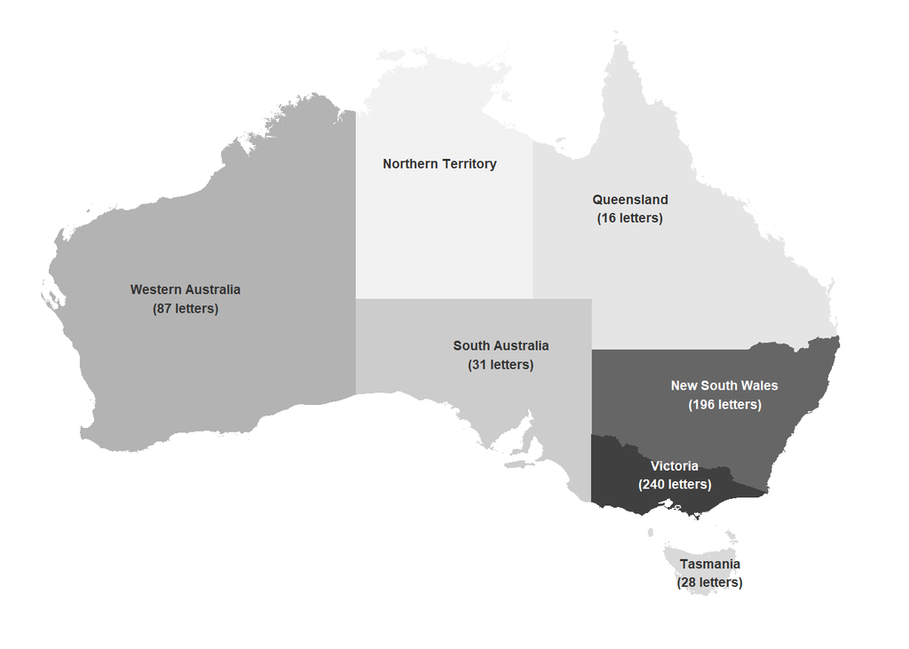

```r
# plot ozmap
ozmap <- ggplot() +
  # plot map
  geom_polygon(data = ozmapt,
               aes(x = long, y = lat, group = group, fill = id),
               asp = 1, colour = NA) +
  # add text
  geom_text(data = cnames, aes(x = long, y = lat, label = id),
            size = 2.5, color = tclrs, fontface = "bold",
            check_overlap = T) +
  # color states
  scale_fill_manual(values = clrs) +
  # define theme and axes
  theme_void() +
  scale_x_continuous(name = "Longitude", limits = c(113, 155)) +
  scale_y_continuous(name = "Latitude", limits = c(-45, -10)) +
  # def. background color
  theme(panel.background = element_rect(fill = "white",
                                        colour = "white",
                                        size = 0.5, linetype = "solid"),
        legend.position = "none")
ggsave(file = here::here("images", "letter_map.png"),
         height = 4,  width = 5, dpi = 320)
# show plot
ozmap
```

# 7 Keyword Analysis

inspect corpus data.

```r
# inspect
head(cooee_clean)
```

```
## # A tibble: 6 x 25
##   Nr    Name          Birth Gender Origin Age   Status Arrival Abode YearWriting
##   <chr> <chr>         <chr> <chr>  <chr>  <chr> <chr>  <chr>   <chr> <chr>
## 1 1-001 Philip, Arth~ 1738  m      GB     50    I      1788    0     1788
## 2 1-010 Fowell, Newt~ 176X  m      GB-E   23    III    1788    0     1788
## 3 1-011 Fowell, Newt~ 176X  m      GB-E   23    III    1788    0     1788
## 4 1-012 Convict Woman ?     f      GB     un    IV     1788    0     1788
## 5 1-014 Worgan, Geor~ 1757  m      GB-E   31    II     1788    0     1788
## 6 1-017 Surgeon's Ma~ ?     m      GB     un    III    1788    2     1790
## # ... with 15 more variables: PlaceWriting <chr>, Register <chr>, TextT <chr>,
## #   Words <int>, GenderAddressee <chr>, StatusAddressee <chr>, Place <chr>,
## #   Source <chr>, Pages <chr>, id <int>, Rawtext <chr>, Text <chr>,
## #   Datecat <fct>, Text_clean <chr>, Text_semiclean <chr>
```

# 8 Extract Keywords

Create training set

```r
train_c <- control_clean %>%
  dplyr::mutate(Label = "nonCOOEE") %>%
  dplyr::select(id, Text_clean, Label)
train_cooee <- cooee_clean %>%
  dplyr::mutate(Label = "COOEE") %>%
  dplyr::select(id, Text_clean, Label)
train <- rbind(train_cooee, train_c)
# inspect
head(train)
```

```
## # A tibble: 6 x 3
##      id Text_clean                                                         Label
##   <int> <chr>                                                              <chr>
## 1     1 dear pleasure sending seeds gladly sent larger quantity person em~ COOEE
## 2    10 latd obsd stood along shore miles distance oclock entrance botany~ COOEE
## 3    11 sirius port jackson june arriv botany jany last passage weeks cap~ COOEE
## 4    12 take first opportunity given acquaint disconsolate situation soli~ COOEE
## 5    14 sirius sydney cove port jackson june dear richard think hear sayi~ COOEE
## 6    17 long since heard home clothes worn threadbare begin think mother ~ COOEE
```

extract uni- to trigrams in cooee

```r
# tokenize, tolower, remove stopwords and create ngrams
cooee_toks <- quanteda::tokens(train_cooee$Text_clean)
cooee_tokngrms <- tokens_ngrams(cooee_toks, n = 1:3)
cooee_ngrmfreq <- train_cooee %>%
  tidytext::unnest_ngrams(cooee_tokngrms, Text_clean, n = 3, n_min = 1, ngram_delim = "_") %>%
  dplyr::count(cooee_tokngrms) %>%
  dplyr::rename("ngram" = colnames(.)[1],
                "cooee" = colnames(.)[2])
# inspect
cooee_ngrmfreq
```

```
## # A tibble: 527,912 x 2
##    ngram                 cooee
##    <chr>                 <int>
##  1 aaron                     1
##  2 aaron_lived               1
##  3 aaron_lived_deritend      1
##  4 aback                     1
##  5 aback_acts                1
##  6 aback_acts_whole          1
##  7 abana                     1
##  8 abana_pharpar             1
##  9 abana_pharpar_ancient     1
## 10 abandon                   9
## # ... with 527,902 more rows
```

extract uni- to trigrams in corpus of late 18 century prose

```r
# tokenize, tolower, remove stopwords and create ngrams
c_toks <- quanteda::tokens(train_c$Text_clean)
c_tokngrms <- tokens_ngrams(c_toks, n = 1:3)
c_ngrmfreq <- train_c %>%
  tidytext::unnest_ngrams(c_tokngrms, Text_clean, n = 3, n_min = 1, ngram_delim = "_") %>%
  dplyr::count(c_tokngrms) %>%
  dplyr::rename("ngram" = colnames(.)[1],
                "cord" = colnames(.)[2])
# inspect
head(c_ngrmfreq)
```

```
##                  ngram cord
## 1               abated    2
## 2       abated_flatter    1
## 3  abated_flatter_will    1
## 4      abated_medicine    1
## 5 abated_medicine_used    1
## 6            abatement    1
```

combine

```r
ngramfreqtb <- dplyr::full_join(cooee_ngrmfreq, c_ngrmfreq, by = "ngram") %>%
  tidyr::replace_na(list(cooee = 0, cord = 0))
# inspect
head(ngramfreqtb)
```

```
## # A tibble: 6 x 3
##   ngram                cooee  cord
##   <chr>                <dbl> <dbl>
## 1 aaron                    1     0
## 2 aaron_lived              1     0
## 3 aaron_lived_deritend     1     0
## 4 aback                    1     0
## 5 aback_acts               1     0
## 6 aback_acts_whole         1     0
```

Prepare for statistical extraction of keywords

```r
keywordtb <- ngramfreqtb %>%
  dplyr::mutate(Total = cooee+cord) %>%
  dplyr::filter(Total > 10) %>%
  dplyr::mutate(TotalTarget = sum(cooee),
                TotalNonTarget = sum(cord),
                NRows = length(ngram)) %>%
  dplyr::rename(Target = cooee,
                NonTarget = cord,
                Word = ngram) %>%
  dplyr::select(-Total)
# inspect data
keywordtb
```

```
## # A tibble: 6,239 x 6
##    Word       Target NonTarget TotalTarget TotalNonTarget NRows
##    <chr>       <dbl>     <dbl>       <dbl>          <dbl> <int>
##  1 abandoned      20         0      259912         119501  6239
##  2 abide           5        11      259912         119501  6239
##  3 abilities      11         6      259912         119501  6239
##  4 able          308        55      259912         119501  6239
##  5 able_give      15         2      259912         119501  6239
##  6 able_make      14         3      259912         119501  6239
##  7 abode          20         1      259912         119501  6239
##  8 aborigines     39         0      259912         119501  6239
##  9 abound         11         0      259912         119501  6239
## 10 abreast        17         0      259912         119501  6239
## # ... with 6,229 more rows
```

Perform statistics

```r
source(here::here("scripts", "CoocStatzFisher.R"))
# extract keywords
keywords <- CoocStatzFisher(keywordtb)
# filter sig. overused words
sigkeywords <- keywords %>%
  dplyr::filter(CorrSignificance != "n.s.",
                Type == "Overuse") %>%
  dplyr::arrange(-phi)
# inspect data
sigkeywords$Word[1:100]; nrow(sigkeywords)
```

```
##   [1] "miles"      "water"      "country"    "creek"      "river"
##   [6] "camp"       "natives"    "south"      "north"      "found"
##  [11] "course"     "camels"     "like"       "wind"       "east"
##  [16] "west"       "range"      "went"       "feet"       "sydney"
##  [21] "large"      "started"    "england"    "horses"     "travelled"
##  [26] "camped"     "trees"      "passed"     "mile"       "hills"
##  [31] "native"     "three"      "distance"   "colony"     "rain"
##  [36] "round"      "though"     "reached"    "nearly"     "ship"
##  [41] "still"      "grass"      "great"      "night"      "little"
##  [46] "arrived"    "high"       "away"       "small"      "fine"
##  [51] "people"     "clock"      "board"      "deg"        "quite"
##  [56] "although"   "feed"       "party"      "beautiful"  "almost"
##  [61] "work"       "four"       "feel"       "government" "travelling"
##  [66] "station"    "returned"   "along"      "long"       "tree"
##  [71] "first"      "melbourne"  "port"       "several"    "mount"
##  [76] "crossed"    "five"       "even"       "home"       "another"
##  [81] "bearing"    "valley"     "shore"      "hill"       "followed"
##  [86] "bush"       "distant"    "felt"       "number"     "australia"
##  [91] "lake"       "named"      "plains"     "hours"      "blacks"
##  [96] "mulga"      "sand"       "governor"   "side"       "island"
```

```
## [1] 2560
```

Select keywords with substantive effect size (phi > .02)

```r
# filter keywords with phi > .2
bigsigkeywords <- sigkeywords %>%
  dplyr::filter(phi > .02)
# save data to disc
readr::write_delim(bigsigkeywords, here::here("tables", "bigsigkeywords.txt"), delim = "\t")
# inspect
bigsigkeywords
```

```
## # A tibble: 22 x 12
##    Word    Target NonTarget TotalTarget TotalNonTarget     p    x2    phi
##    <chr>    <dbl>     <dbl>       <dbl>          <dbl> <dbl> <dbl>  <dbl>
##  1 miles     2033         4      259912         119501     0  928. 0.0495
##  2 water     1521        87      259912         119501     0  508. 0.0366
##  3 country   1246        48      259912         119501     0  463. 0.0349
##  4 creek      610         0      259912         119501     0  280. 0.0271
##  5 river      666        14      259912         119501     0  272. 0.0268
##  6 camp       593         1      259912         119501     0  269. 0.0266
##  7 natives    554         0      259912         119501     0  254. 0.0259
##  8 south      518         2      259912         119501     0  232. 0.0247
##  9 north      520         7      259912         119501     0  221. 0.0241
## 10 found      918       102      259912         119501     0  218  0.024
## # ... with 12 more rows, and 4 more variables: RateTarget <dbl>,
## #   RateNonTarget <dbl>, Type <chr>, CorrSignificance <chr>
```

Extract relative frequency in COOEE

```r
cooeeterms <- sigkeywords$Word
cooee_regex <- paste0("\\b", cooeeterms, "\\b|", collapse = "")
# extract frequencies
cooeefreq <- cooee_clean %>%
  dplyr::select(Datecat, Text_clean, Words) %>%
  dplyr::mutate(Frequency = stringr::str_count(Text_clean, cooee_regex),
                RFrequency = Frequency/Words*100) %>%
  dplyr::group_by(Datecat) %>%
  dplyr::summarise(RelativeFrequency = mean(RFrequency)) %>%
  dplyr::mutate(NumDate = 1:length(Datecat),
                Datecat = factor(Datecat))
# inspect data
cooeefreq
```

```
## # A tibble: 6 x 3
##   Datecat   RelativeFrequency NumDate
##   <fct>                 <dbl>   <int>
## 1 1788-1800              190.       1
## 2 1801-1820              194.       2
## 3 1821-1840              192.       3
## 4 1841-1860              189.       4
## 5 1861-1880              177.       5
## 6 1881-1900              170.       6
```

Plot relative frequency of cooee texts

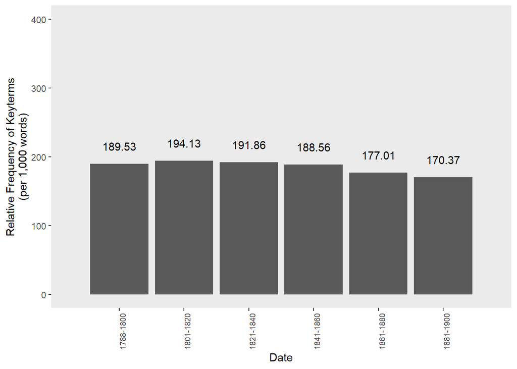

```r
ggplot(cooeefreq, aes(x = NumDate, y = RelativeFrequency, label = round(RelativeFrequency, 2))) +
  geom_bar(stat = "identity") +
  scale_x_discrete(breaks = cooeefreq$NumDate,
                   labels = cooeefreq$Datecat,
                   limits = 1: max(cooeefreq$NumDate)) +
  labs(x = "Date", y = "Relative Frequency of Keyterms\n(per 1,000 words)") +
  theme_set(theme_bw(base_size = 10)) +
  theme(legend.position="none",
        panel.grid.major = element_blank(),
        panel.grid.minor = element_blank(),
        axis.text.x = element_text(angle = 90, size =7.5)) +
  geom_text(vjust=-1.6, color = "black") +
  coord_cartesian(ylim = c(0, 400))
```

Plot relative frequencies of Oz terms

```r
keywordselection <- c("convicts", "family", "natives",
                      "australia", "colony", "ship",
                      "creek", "travelled", "journey")
# extract frequencies
kwfreqs <- cooee_clean %>%
  dplyr::select(YearWriting, Text_clean, Words, Datecat) %>%
  dplyr::group_by(YearWriting) %>%
  dplyr::summarise(Text_clean = paste(Text_clean, collapse = " "),
                   Words = sum(Words),
                   Datecat = Datecat) %>%
  dplyr::ungroup() %>%
  unnest_tokens(Word, Text_clean) %>%
  dplyr::filter(Word %in% keywordselection) %>%
  dplyr::group_by(Word, YearWriting) %>%
  dplyr::summarise(NoWords = n(),
                   Percent = NoWords/unique(Words)*100,
                   Datecat = Datecat) %>%
  dplyr::ungroup() %>%
  dplyr::select(-NoWords) %>%
  dplyr::mutate(YearWriting = factor(YearWriting),
                NumDate = as.numeric(YearWriting),
                Word = factor(Word))
# inspect data
head(kwfreqs)
```

```
## # A tibble: 6 x 5
##   Word      YearWriting Percent Datecat   NumDate
##   <fct>     <fct>         <dbl> <fct>       <dbl>
## 1 australia 1821         0.0392 1821-1840      31
## 2 australia 1821         0.0392 1821-1840      31
## 3 australia 1821         0.0392 1821-1840      31
## 4 australia 1821         0.0392 1821-1840      31
## 5 australia 1821         0.0392 1821-1840      31
## 6 australia 1821         0.0392 1821-1840      31
```

Plot frequencies of selected keywords as line graph

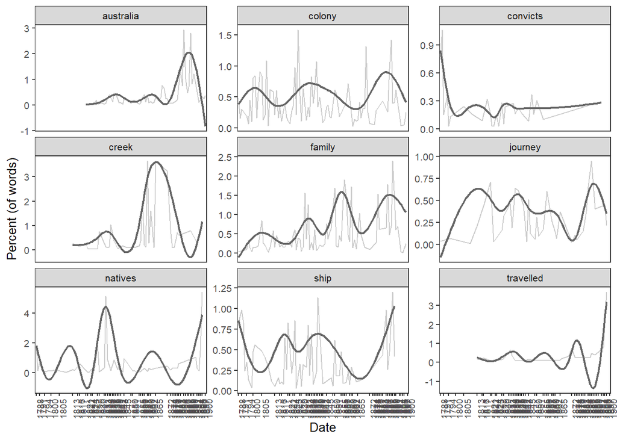

```r
p7d <- kwfreqs %>%
  dplyr::mutate(YearWriting = factor(YearWriting),
                NumDate = as.numeric(YearWriting),
                Word = factor(Word))

ggplot(p7d, aes(x = NumDate, y = Percent)) +
  facet_wrap(vars(Word), ncol = 3, scales="free_y") +
  geom_line(color = "gray80", size = .5) +
  geom_smooth(se = F, span = .4, color = "gray40", size = .75) +
  scale_x_discrete(breaks = p7d$NumDate[seq(1, length(p7d$NumDate), by = 100)],
                   labels = p7d$YearWriting[seq(1, length(p7d$YearWriting), by = 100)],
                   limit = 1:length(p7d$YearWriting)) +
  labs(x = "Date", y = "Percent (of words)") +
  theme_set(theme_bw(base_size = 12)) +
  theme(legend.position="none",
        panel.grid.major = element_blank(),
        panel.grid.minor = element_blank(),
        axis.text.x = element_text(angle = 90, size =7))
```

```r
ggsave(file = here::here("images", "selected_keywords.png"),
         height = 7,  width = 14, dpi = 320)
```

With periods

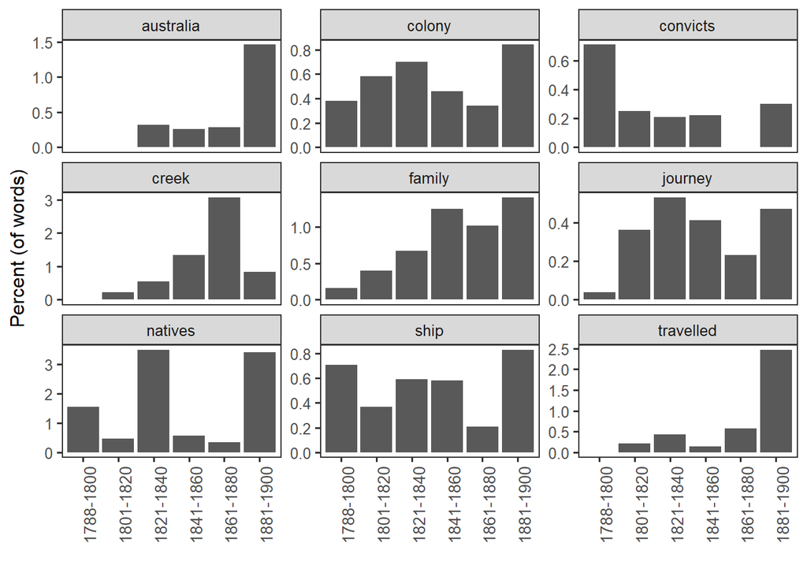

```r
p7d %>%
  dplyr::group_by(Datecat, Word) %>%
  dplyr::summarise(Percent = round(mean(Percent), 2)) %>%
  ggplot(aes(x = Datecat, y = Percent)) +
  facet_wrap(vars(Word), ncol = 3, scales="free_y") +
  geom_bar(stat = "identity", size = .5) +
  labs(x = "", y = "Percent (of words)") +
  theme_set(theme_bw(base_size = 12)) +
  theme(legend.position="none",
        panel.grid.major = element_blank(),
        panel.grid.minor = element_blank(),
        axis.text.x = element_text(angle = 90, size =10))
```

```r
ggsave(file = here::here("images", "selected_keywords_bar.png"),
         height = 5,  width = 7, dpi = 320)
```

# 9 Keywords by Period

convert data: have date, ngram, and frequencies of ngrams

```r
# tokenize and create ngram freqs
cooee_ngrmfreq <- cooee_clean %>%
  dplyr::select(id, Datecat, Text_clean) %>%
  dplyr::group_by(Datecat) %>%
  tidytext::unnest_ngrams(cooee_tokngrms, Text_clean, n = 1, n_min = 1, ngram_delim = "_") %>%
  dplyr::count(cooee_tokngrms) %>%
  dplyr::rename("Period" = colnames(.)[1],
                "Word" = colnames(.)[2],
                "Freq" = colnames(.)[3]) %>%
  dplyr::rowwise() %>%
  dplyr::mutate(Period = paste0("Period_", Period))
# inspect
cooee_ngrmfreq
```

```
## # A tibble: 49,308 x 3
## # Rowwise:  Period
##    Period           Word       Freq
##    <chr>            <chr>     <int>
##  1 Period_1788-1800 abandoned     1
##  2 Period_1788-1800 abate         1
##  3 Period_1788-1800 abated        2
##  4 Period_1788-1800 abbeys        1
##  5 Period_1788-1800 abcondon      1
##  6 Period_1788-1800 abide         1
##  7 Period_1788-1800 abilities     6
##  8 Period_1788-1800 ability       1
##  9 Period_1788-1800 abject        1
## 10 Period_1788-1800 abjure        1
## # ... with 49,298 more rows
```

convert to wide

```r
cooee_ngrmfreq_wd <- cooee_ngrmfreq %>%
  tidyr::spread(Period, Freq) %>%
  replace(is.na(.), 0) %>%
  dplyr::filter(nchar(Word) > 2)
# inspect
cooee_ngrmfreq_wd
```

```
## # A tibble: 23,353 x 7
##    Word    `Period_1788-180~ `Period_1801-182~ `Period_1821-18~ `Period_1841-18~
##    <chr>               <int>             <int>            <int>            <int>
##  1 aaron                   0                 0                0                1
##  2 aback                   0                 0                0                1
##  3 abana                   0                 0                0                1
##  4 abandon                 0                 1                0                0
##  5 abando~                 1                 1                8                1
##  6 abando~                 0                 0                0                0
##  7 abando~                 0                 0                0                1
##  8 abashed                 0                 0                1                0
##  9 abate                   1                 0                1                0
## 10 abated                  2                 0                2                0
## # ... with 23,343 more rows, and 2 more variables: Period_1861-1880 <int>,
## #   Period_1881-1900 <int>
```

function fro keyword extraction

```r
pdperiod <- function(perioddata, Targetperiod){
  periodtb <- perioddata %>%
    tidyr::gather(Period, Frequency, `Period_1788-1800`:`Period_1881-1900`) %>%
    dplyr::mutate(Period = ifelse(Period != Targetperiod, "Other", Period)) %>%
    dplyr::group_by(Period, Word) %>%
    dplyr::mutate(Frequency = sum(Frequency)) %>%
    unique() %>%
    tidyr::spread(Period, Frequency) %>%
    dplyr::rename(Target = Targetperiod, NonTarget = Other) %>%
    dplyr::ungroup() %>%
    dplyr::mutate(TotalTarget = sum(Target), TotalNonTarget = sum(NonTarget),
                  NRows = n())
  periodkeys <- CoocStatzFisher(periodtb)
  periodkeys <- periodkeys %>%
    dplyr::filter(CorrSignificance != "n.s.") %>%
    dplyr::mutate(Period = rep(Targetperiod, length(CorrSignificance)))
  return(periodkeys)
}
```

Extract keywords

```r
keys_period1 <- pdperiod(cooee_ngrmfreq_wd, "Period_1788-1800")
keys_period2 <- pdperiod(cooee_ngrmfreq_wd, "Period_1801-1820")
keys_period3 <- pdperiod(cooee_ngrmfreq_wd, "Period_1821-1840")
keys_period4 <- pdperiod(cooee_ngrmfreq_wd, "Period_1841-1860")
keys_period5 <- pdperiod(cooee_ngrmfreq_wd, "Period_1861-1880")
keys_period6 <- pdperiod(cooee_ngrmfreq_wd, "Period_1881-1900")
# inspect data
head(keys_period1)
```

```
## # A tibble: 6 x 13
##   Word     NonTarget Target TotalTarget TotalNonTarget     p    x2    phi
##   <chr>        <int>  <int>       <int>          <int> <dbl> <dbl>  <dbl>
## 1 wind           205    216       24205         261228     0  991. 0.0589
## 2 steard           0     68       24205         261228     0  722. 0.0503
## 3 iland            0     48       24205         261228     0  506. 0.0421
## 4 norfolk         13     51       24205         261228     0  409. 0.0379
## 5 convicts        51     69       24205         261228     0  365. 0.0358
## 6 oclock          27     58       24205         261228     0  384. 0.0367
## # ... with 5 more variables: RateTarget <dbl>, RateNonTarget <dbl>, Type <chr>,
## #   CorrSignificance <chr>, Period <chr>
```

Combine keywords

```r
period_keys <- rbind(keys_period1, keys_period2, keys_period3,
                     keys_period4, keys_period5, keys_period6) %>%
  dplyr::arrange(-phi)
# inspect data
head(period_keys)
```

```
## # A tibble: 6 x 13
##   Word   NonTarget Target TotalTarget TotalNonTarget     p    x2    phi
##   <chr>      <int>  <int>       <int>          <int> <dbl> <dbl>  <dbl>
## 1 creek        193    417       45894         239539     0 1234. 0.0658
## 2 wind         205    216       24205         261228     0  991. 0.0589
## 3 steard         0     68       24205         261228     0  722. 0.0503
## 4 deg            0    217       67213         218220     0  701. 0.0496
## 5 camels       102    326       67213         218220     0  656. 0.048
## 6 miles       1081    952       67213         218220     0  615. 0.0464
## # ... with 5 more variables: RateTarget <dbl>, RateNonTarget <dbl>, Type <chr>,
## #   CorrSignificance <chr>, Period <chr>
```

## 9.1 Save data (period_keys)

```r
base::saveRDS(period_keys, file = here::here("data", "period_keys.rda"))
base::saveRDS(sigkeywords, file = here::here("data", "sigkeywords.rda"))
```

```r
# load data
cooee_clean  <- base::readRDS(file = here::here("data", "cooee_clean.rda"))
period_keys  <- base::readRDS(file = here::here("data", "period_keys.rda"))
sigkeywords  <- base::readRDS(file = here::here("data", "sigkeywords.rda"))
# inspect
nrow(cooee_clean); nrow(period_keys)
```

```
## [1] 607
```

```
## [1] 2946
```

# 10 Visualize keywords

```r
p1d <- period_keys %>%
  dplyr::mutate(Period = dplyr::case_when(Period == "Period_1788-1800" ~ 1,
                                          Period == "Period_1801-1820" ~ 2,
                                          Period == "Period_1821-1840" ~ 3,
                                          Period == "Period_1841-1860" ~ 4,
                                          Period == "Period_1861-1880" ~ 5,
                                          Period == "Period_1881-1900" ~ 6,
                                          TRUE ~ 7)) %>%
  dplyr::filter(CorrSignificance == "p<.001") %>%
  dplyr::filter(Word != "other") %>%
#  dplyr::filter(phi > .001) %>%
  dplyr::mutate(x2 = log(x2)) %>%
  dplyr::mutate(x2 = ifelse(Type == "Overuse", x2, -x2))
# inspect
head(p1d)
```

```
## # A tibble: 6 x 13
##   Word   NonTarget Target TotalTarget TotalNonTarget     p    x2    phi
##   <chr>      <int>  <int>       <int>          <int> <dbl> <dbl>  <dbl>
## 1 creek        193    417       45894         239539     0  7.12 0.0658
## 2 wind         205    216       24205         261228     0  6.90 0.0589
## 3 steard         0     68       24205         261228     0  6.58 0.0503
## 4 deg            0    217       67213         218220     0  6.55 0.0496
## 5 camels       102    326       67213         218220     0  6.49 0.048
## 6 miles       1081    952       67213         218220     0  6.42 0.0464
## # ... with 5 more variables: RateTarget <dbl>, RateNonTarget <dbl>, Type <chr>,
## #   CorrSignificance <chr>, Period <dbl>
```

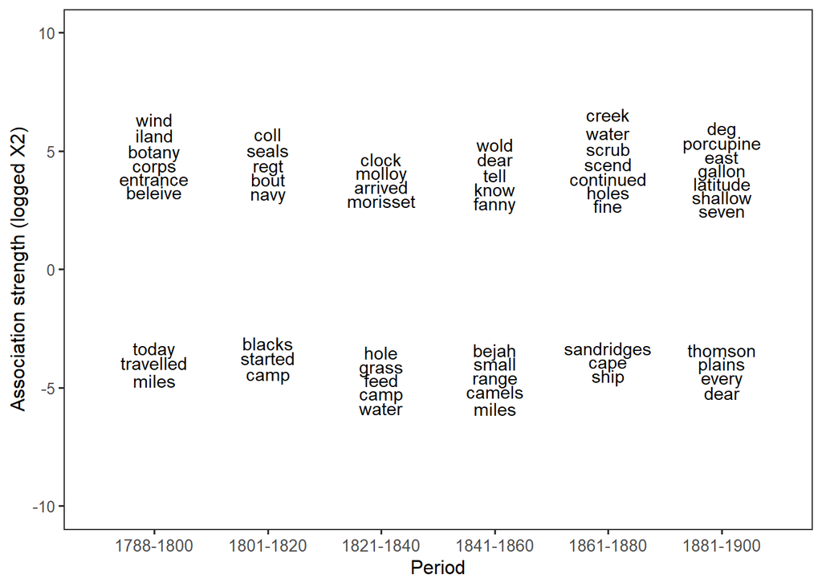

```r
keyperiod <- ggplot(p1d, aes(x = Period, y = x2)) +
#  geom_point()+
  #geom_text(aes(label=Word),hjust=0, vjust=-1,
  #          position=position_jitter(width=.5,height=1), size = 2) +
  geom_text(aes(label = Word), check_overlap = TRUE, vjust = 1.5) +
  labs(x = "Period", y = "Association strength (logged X2)") +
  scale_x_continuous(breaks = seq(1, 6, 1),
                     labels= str_remove_all(names(table(period_keys$Period)), "Period_"),
                     limits = c(0.5, 6.5)) +
  theme_set(theme_bw(base_size = 10)) +
  theme(legend.position="none",
        panel.grid.major = element_blank(),
        panel.grid.minor = element_blank(),
        axis.text.x = element_text(angle = 0, size =10),
        plot.margin = unit(c(.2, .2, .2, .2), "cm")) +
  coord_cartesian(ylim = c(-10, 10))
ggsave(file = here::here("images", "Keyterms_Period.png"),
         height = 4,  width = 6, dpi = 320)
keyperiod
```

prepare data

```r
cooee_sent <- tokenize_sentence(cooee_clean$Text_semiclean) %>%
  unlist() %>%
  tolower %>%
  stemDocument()
# check
length(cooee_sent); head(cooee_sent)
```

```
## [1] 13916
```

```
## [1] "dear , pleasur send seed & glad sent larger quantity, person employed, either neglect collect proper time, late season."
## [2] "kanguroo stuffed, alarm ladi banks, will observ feet differ describ voyage."
## [3] "these anim numerous, fire grow stone . send account appear metal & ochre, found river, raini season run thro slate quarry."
## [4] "slate, accord inform slater, fitt rotten & will split, skin bird send sydney merit attention, differ ostrich & . seen sever difficult within shot ."
## [5] "black swan seen frequent killed. situat peni kangurroo appear uncommon, anus & testicles, & close former."
## [6] "this anim grow great size, kill weigh near hundr weight, & found dead woods, tail , measur eighteen inch circumference. procur shelter & secur & provis give full employment, made excurs order examin countri around , difficulti , dear , form just idea . inland countri timber grow observ botan…
```

```r
# convert to corpus
cooee_corpus <- corpus(cooee_sent)
```

reduce sig keywords

```r
sigkeywords <- sigkeywords %>%
  dplyr::arrange(-phi) %>%
  dplyr::filter(phi > 0.0175)
# inspect
head(sigkeywords); nrow(sigkeywords)
```

```
## # A tibble: 6 x 12
##   Word    Target NonTarget TotalTarget TotalNonTarget     p    x2    phi
##   <chr>    <dbl>     <dbl>       <dbl>          <dbl> <dbl> <dbl>  <dbl>
## 1 miles     2033         4      259912         119501     0  928. 0.0495
## 2 water     1521        87      259912         119501     0  508. 0.0366
## 3 country   1246        48      259912         119501     0  463. 0.0349
## 4 creek      610         0      259912         119501     0  280. 0.0271
## 5 river      666        14      259912         119501     0  272. 0.0268
## 6 camp       593         1      259912         119501     0  269. 0.0266
## # ... with 4 more variables: RateTarget <dbl>, RateNonTarget <dbl>, Type <chr>,
## #   CorrSignificance <chr>
```

```
## [1] 41
```

# 11 Network

extract uni- to trigrams in cooee

```r
# tokenize, tolower, remove stopwords and create ngrams
cooee_ngrmfreq <- cooee_clean %>%
  group_by(id) %>%
  tidytext::unnest_ngrams(cooee_tokngrms, Text_clean, n = 1, n_min = 1, ngram_delim = "_") %>%
  dplyr::count(cooee_tokngrms) %>%
  dplyr::rename("letter" = colnames(.)[1],
                "word" = colnames(.)[2],
                "freq" = colnames(.)[3]) %>%
  dplyr::filter(word %in% sigkeywords$Word) %>%
  tidyr::spread(word, freq) %>%
  replace(is.na(.), 0)
# remove letter
cooee_ngrmfreq <-cooee_ngrmfreq[, 2:ncol(cooee_ngrmfreq)]
# inspect
cooee_ngrmfreq
```

```
## # A tibble: 558 x 41
##    camels  camp camped colony country course creek distance  east england  feet
##     <int> <int>  <int>  <int>   <int>  <int> <int>    <int> <int>   <int> <int>
##  1      0     0      0      0       5      0     0        1     0       0     1
##  2      0     0      0      0       0      0     0        4     0       0     5
##  3      0     2      0      7       9      1     0        6     5      12    22
##  4      0     0      0      0       0      0     0        0     0       1     0
##  5      0     0      0      6       5      0     0        4     0       1     0
##  6      0     0      0      0       4      0     0        0     0       0     0
##  7      0     0      0      0       0      0     0        0     0       2     0
##  8      0     0      0      1       0      0     0        1     0       0     0
##  9      0     0      0      0       0      0     0        0     0       2     0
## 10      0     1      0      0       0      0     0        0     0       1     0
## # ... with 548 more rows, and 30 more variables: found <int>, hills <int>,
## #   horses <int>, large <int>, like <int>, mile <int>, miles <int>,
## #   native <int>, natives <int>, nearly <int>, north <int>, passed <int>,
## #   rain <int>, range <int>, reached <int>, river <int>, round <int>,
## #   ship <int>, south <int>, started <int>, still <int>, sydney <int>,
## #   though <int>, three <int>, travelled <int>, trees <int>, water <int>,
## #   went <int>, west <int>, wind <int>
```

create dfm

```r
# create a document feature matrix
cooee_dfm <- quanteda::as.dfm(cooee_ngrmfreq)
# create feature co-occurrence matrix
cooee_fcm <- quanteda::fcm(cooee_dfm)
# inspect data
head(cooee_fcm)
```

```
## Feature co-occurrence matrix of: 6 by 41 features.
##          features
## features  camels  camp camped colony country course creek distance  east
##   camels   38996 56748  26383     70   39719  27004 20743    11848 44113
##   camp         0 26192  22232    199   36217  26135 32125    12119 34537
##   camped       0     0   5831    136   17264  11095 13008     5289 15406
##   colony       0     0      0    299    1086    369   217      319   257
##   country      0     0      0      0   17089  21302 23593    10175 25146
##   course       0     0      0      0       0   8514 20466     7368 17717
##          features
## features  england
##   camels        6
##   camp        227
##   camped       95
##   colony      569
##   country    1146
##   course      575
## [ reached max_nfeat ... 31 more features ]
```

generate network

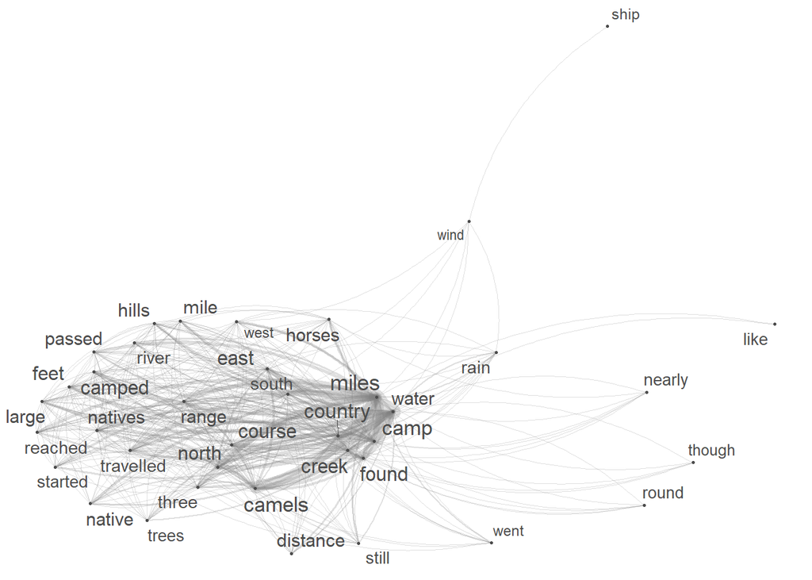

```r
cnet <- quanteda.textplots::textplot_network(cooee_fcm,
                                     min_freq = .5,
                                     edge_alpha = 0.25,
                                     edge_color = "gray50",
                                     vertex_labelsize = log(rowSums(cooee_fcm))/3,
                                     vertex_size = .5,
                                     max.overlaps = max.overlaps*2 )
ggsave(file = here::here("images", "net_cooee.png"),
         height = 4,  width = 6, dpi = 320)
# inspect
cnet
```

# 12 Topic Modelling

Create corpus and DTM

```r
toks_cooee <- quanteda::tokens(cooee_corpus,
                    remove_punct = TRUE,
                    remove_numbers = TRUE,
                    remove_symbol = TRUE)
dfmat_cooee <- dfm(toks_cooee) %>%
              dfm_trim(min_termfreq = 0.2,
                       termfreq_type = "quantile",
                       max_docfreq = 0.2,
                       docfreq_type = "prop")
# inspect
dfmat_cooee[1:10, 1:10]
```

```
## Document-feature matrix of: 10 documents, 10 features (85.00% sparse) and 0 docvars.
##        features
## docs    dear pleasur send seed glad sent larger quantity person employed
##   text1    1       1    1    1    1    1      1        1      1        1
##   text2    0       0    0    0    0    0      0        0      0        0
##   text3    0       0    1    0    0    0      0        0      0        0
##   text4    0       0    1    0    0    0      0        0      0        0
##   text5    0       0    0    0    0    0      0        0      0        0
##   text6    1       0    0    0    0    0      0        0      0        0
## [ reached max_ndoc ... 4 more documents ]
```

## 12.1 Unsupervised LDA

change k to set different N of topics

```r
# set seed
set.seed(1234)
# generate model
tmod_lda <- seededlda::textmodel_lda(dfmat_cooee, k = 6)
readr::write_delim(as.data.frame(terms(tmod_lda, 10)), here::here("tables", "topic_keys.txt"), delim = "\t")
# inspect
terms(tmod_lda, 10)
```

```
##       topic1   topic2    topic3   topic4   topic5  topic6
##  [1,] "will"   "great"   "wind"   "mile"   "will"  "went"
##  [2,] "dear"   "upon"    "ship"   "water"  "good"  "came"
##  [3,] "letter" "everi"   "night"  "camp"   "work"  "black"
##  [4,] "know"   "time"    "arriv"  "creek"  "well"  "nativ"
##  [5,] "time"   "will"    "sunday" "miles"  "make"  "they"
##  [6,] "think"  "appear"  "clock"  "travel" "year"  "night"
##  [7,] "hope"   "without" "land"   "river"  "place" "littl"
##  [8,] "well"   "part"    "board"  "found"  "week"  "said"
##  [9,] "good"   "present" "morn"   "hill"   "come"  "white"
## [10,] "write"  "person"  "boat"   "north"  "land"  "made"
```

## 12.2 Supervised LDA

```r
# semisupervised LDA
dict <- dictionary(list(family = c("family", "dear", "home", "mother",
                                   "father", "son", "daugther"),
                        journey = c("ship", "wind", "ocean", "travel", "arriv", "board"),
                        landscape = c("creek", "river", "australia", "hill", "water"),
                        exploration = c("camp", "camel", "hors*"),
                        indiginous = c("black", "nativ*", "aborig*", "chief"),
                        employment = c("work", "money", "pay", "week", "good", "gold")))
tmod_slda <- textmodel_seededlda(dfmat_cooee, dict, residual = TRUE, min_termfreq = 10)
terms(tmod_slda)
```

```
##       family   journey  landscape   exploration indiginous   employment
##  [1,] "dear"   "travel" "water"     "camp"      "nativ"      "good"
##  [2,] "home"   "wind"   "river"     "hors"      "black"      "work"
##  [3,] "mother" "arriv"  "creek"     "camel"     "natives"    "week"
##  [4,] "father" "ship"   "hill"      "horses"    "chief"      "money"
##  [5,] "family" "board"  "australia" "horse"     "aborigin"   "gold"
##  [6,] "son"    "ocean"  "mile"      "horseback" "native"     "pay"
##  [7,] "will"   "land"   "miles"     "night"     "aborigines" "will"
##  [8,] "letter" "clock"  "north"     "start"     "they"       "make"
##  [9,] "know"   "south"  "countri"   "last"      "white"      "well"
## [10,] "time"   "sail"   "found"     "return"    "like"       "year"
##       other
##  [1,] "great"
##  [2,] "will"
##  [3,] "everi"
##  [4,] "upon"
##  [5,] "time"
##  [6,] "without"
##  [7,] "present"
##  [8,] "person"
##  [9,] "part"
## [10,] "make"
```

save keyterms

```r
readr::write_delim(as.data.frame(terms(tmod_slda)), here::here("tables", "topic_keys.txt"), delim = "\t")
# inspect
terms(tmod_slda, 10)
```

```
##       family   journey  landscape   exploration indiginous   employment
##  [1,] "dear"   "travel" "water"     "camp"      "nativ"      "good"
##  [2,] "home"   "wind"   "river"     "hors"      "black"      "work"
##  [3,] "mother" "arriv"  "creek"     "camel"     "natives"    "week"
##  [4,] "father" "ship"   "hill"      "horses"    "chief"      "money"
##  [5,] "family" "board"  "australia" "horse"     "aborigin"   "gold"
##  [6,] "son"    "ocean"  "mile"      "horseback" "native"     "pay"
##  [7,] "will"   "land"   "miles"     "night"     "aborigines" "will"
##  [8,] "letter" "clock"  "north"     "start"     "they"       "make"
##  [9,] "know"   "south"  "countri"   "last"      "white"      "well"
## [10,] "time"   "sail"   "found"     "return"    "like"       "year"
##       other
##  [1,] "great"
##  [2,] "will"
##  [3,] "everi"
##  [4,] "upon"
##  [5,] "time"
##  [6,] "without"
##  [7,] "present"
##  [8,] "person"
##  [9,] "part"
## [10,] "make"
```

inspect key terms

```r
topics(tmod_slda)[1:20]
```

```
##  [1] other      journey    landscape  indiginous indiginous landscape
##  [7] other      indiginous indiginous other      landscape  indiginous
## [13] family     journey    journey    journey    landscape  journey
## [19] journey    journey
## Levels: family journey landscape exploration indiginous employment other
```

check predicted topics

```r
length(topics(tmod_slda))
```

```
## [1] 13916
```

```r
head(topics(tmod_slda), 20)
```

[output not shown]

# 13 Topic by period

create index of how many sentences are in each letter

```r
cooee_idx <- sapply(cooee_clean$Text_semiclean, function(x){
  x <- tokenize_sentence(x)
  x <- sapply(x, function(y){ length(y) })
})
cooee_idx <- as.vector(cooee_idx)
# inspect
head(cooee_idx)
```

```
## [1]  14  26 189   7  37   3
```

generate data frame with topic for each sentence plus period

```r
Letters <- rep(cooee_clean$Nr, cooee_idx)
Date <- rep(cooee_clean$YearWriting, cooee_idx)
Period <- rep(cooee_clean$Datecat, cooee_idx)
Topics <- topics(tmod_slda)
Id <- 1:length(Topics)
# generate df
cooee_df <- data.frame(Id, Letters, Date, Period, Topics) %>%
  dplyr::group_by(Period, Topics) %>%
  dplyr::summarise(Freq = n()) %>%
  dplyr::ungroup() %>%
  dplyr::mutate(Topics = dplyr::case_when(Topics == "family" ~ "Topic1_family",
                                          Topics == "journey" ~ "Topic2_journey",
                                          Topics == "landscape" ~ "Topic3_landscape",
                                          Topics == "exploration" ~ "Topic4_exploration",
                                          Topics == "indiginous" ~ "Topic5_indiginous",
                                          Topics == "employment" ~ "Topic6_eployment",
                                          Topics == "other" ~ "Topic7_other")) %>%
  tidyr::drop_na() %>%
  dplyr::group_by(Period) %>%
  dplyr::mutate(Sum = sum(Freq),
                Percent = round(Freq/Sum*100, 1))
# save data
readr::write_delim(cooee_df, here::here("tables", "cooee_df.txt"), delim = "\t")
# inspect
head(cooee_df, 10)
```

```
## # A tibble: 10 x 5
## # Groups:   Period [2]
##    Period    Topics              Freq   Sum Percent
##    <fct>     <chr>              <int> <int>   <dbl>
##  1 1788-1800 Topic1_family        102  1208     8.4
##  2 1788-1800 Topic2_journey       444  1208    36.8
##  3 1788-1800 Topic3_landscape     111  1208     9.2
##  4 1788-1800 Topic4_exploration    70  1208     5.8
##  5 1788-1800 Topic5_indiginous    129  1208    10.7
##  6 1788-1800 Topic6_eployment      85  1208     7
##  7 1788-1800 Topic7_other         267  1208    22.1
##  8 1801-1820 Topic1_family        237   887    26.7
##  9 1801-1820 Topic2_journey       159   887    17.9
## 10 1801-1820 Topic3_landscape     106   887    12
```

plot

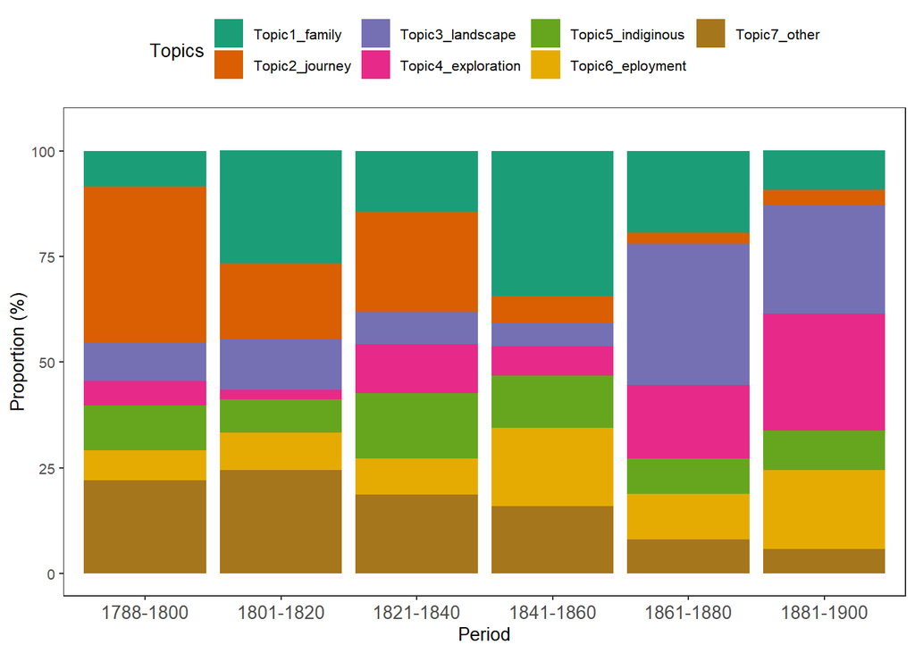

```r
cooee_df %>%
  ggplot(aes(x = Period, y = Percent, group = Topics, fill = Topics)) +
  geom_bar(stat = "identity", position="stack") +
  #scale_fill_grey() +
  scale_fill_brewer(palette="Dark2") +
  theme(legend.position="top",
        panel.grid.major = element_blank(),
        panel.grid.minor = element_blank(),
        axis.text.x = element_text(angle = 0, size =10)) +
  scale_y_continuous(name = "Proportion (%)",
                   breaks = seq(0, 100, 25),
                   labels = seq(0, 100, 25),
                   limits = c(0, 105))
```

```r
ggsave(file = here::here("images", "topic_cooee_col.png"),
         height = 4,  width = 7.5, dpi = 320)
```

# 14 Outro

# References

Denison, David, and Linda van Bergen. 2003. “A Corpus of Late 18c Prose (Cord).” The University of Manchester. https://varieng.helsinki.fi/CoRD/.

Fritz, Clemens. 2004. “Corpus of Oz Early English (Cooee).” Berlin: Free University of Berlin. https://www.ausnc.org.au/corpora/cooee.